# Relationship between variables and miles per gallon

## Executive Summary

### Task

You work for Motor Trend, a magazine about the automobile industry. Looking at a data set of a collection of cars, they are interested in exploring the relationship between a set of variables and miles per gallon (MPG) (outcome). They are particularly interested in the following two questions:

- “Is an automatic or manual transmission better for MPG”
- “Quantify the MPG difference between automatic and manual transmission”

### Analysis

#### Data description and summary

The first step of our analysis is to load the `mtcard` dataset and check its data structure.

```r
data("mtcars")
str(mtcars)
```

```
## 'data.frame':    32 obs. of  11 variables:
##  $ mpg : num  21 21 22.8 21.4 18.7 18.1 14.3 24.4 22.8 19.2 ...
##  $ cyl : num  6 6 4 6 8 6 8 4 4 6 ...
##  $ disp: num  160 160 108 258 360 ...
##  $ hp  : num  110 110 93 110 175 105 245 62 95 123 ...
##  $ drat: num  3.9 3.9 3.85 3.08 3.15 2.76 3.21 3.69 3.92 3.92 ...
##  $ wt  : num  2.62 2.88 2.32 3.21 3.44 ...
##  $ qsec: num  16.5 17 18.6 19.4 17 ...
##  $ vs  : num  0 0 1 1 0 1 0 1 1 1 ...
##  $ am  : num  1 1 1 0 0 0 0 0 0 0 ...
##  $ gear: num  4 4 4 3 3 3 3 4 4 4 ...
##  $ carb: num  4 4 1 1 2 1 4 2 2 4 ...
```

Now we will focus on study the relation between the type of transmission and the number of miles per gallon, `am` (0 = automatic and 1 = manual) and `mpg` variables respectively.

#### Exploration Data analysis

We will plot some relations between the transmission `am` and miles per gallon `mpg` in order to identify it help us to identify any patterns. We will work with `ggplot2` and `GGally` library so we need to load both.

```r
library(ggplot2);library(GGally)
```

Our first figure will show the values of MPG related to manual and automatic cars but first we will add factor and label it as automatic and manual transmission.

```r
mtcars$trans <- factor(mtcars$am, labels = c("automatic", "manual"))
```

```r
plot1 <- ggplot(mtcars, aes(x=mpg, fill = factor(mtcars$trans))) + theme_bw() +
  geom_bar( binwidth = 1, col = 'black', position="dodge") + labs( fill = 'Transmission') +
  labs( title = "Fig 1. Miles per gallon", x = "MPG")
```

From the Fig 1. (attached to the appendix) we can identify that manual cars have a higher values on miles per gallon. Following the Fig 2. a boxplot for miles per gallon and transmission.

```r
plot2 <- ggplot(mtcars, aes(x=factor(mtcars$trans), y=mpg, fill = factor(mtcars$trans))) +
  geom_boxplot(adjust = 1) + geom_jitter(size = 3) + labs( fill = 'Transmission') +
  labs( title = 'Fig 2. MPG for transmission', x = 'Transmission', y = 'MPG')
```

As you can see in both figures attached in the appendix, seems that there is some pattern between MPG and Transmission, anyway this patterns can not be explained just with this evidences. We have to check if it is related to other variables. In order to check this relations we can proceed by plot correlation heatmap which show us in which measure the variables are correlated.

```
heatmap(cor(mtcars[1:11]), main= "mtcars dataset heatmap correlation")
```

#### Regression models

In this section we will study a simple model and a multivariable model.

##### Simple model

Following we will give an estimation of the effect of transmission on miles per gallon. In order to do that we will build a linear model and compute the confidence interval.

```r
simple_model <-lm(mpg ~ trans, data=mtcars)
model_coef <- summary(simple_model)$coefficients
model_coef
```

```
##              Estimate Std. Error   t value     Pr(>|t|)
## (Intercept) 17.147368   1.124603 15.247492 1.133983e-15
## transmanual  7.244939   1.764422  4.106127 2.850207e-04
```

And the interval:

```r
interval_simple <- model_coef[2,1] + c(-1,1) * qt(0.975, df = simple_model$df) * model_coef[2,2]
interval_simple
```

```
## [1]  3.64151 10.84837
```

Considering the model and the results, compared both transmisions we can conclude that a manual transmission increases on average 7.2449393 miles per gallon over the automatic transmission and the 95% confidence interval is [3.6415096, 10.848369]

For complet the analysis in a simple model we can plot the residuals and check for heteroskedasticity that suggest the presence of more variables.

```r
plot3 <- ggplot(mtcars, aes(x = trans, y = resid(simple_model), fill = trans)) +
  theme_bw() + geom_boxplot(adjust = 1)  + geom_jitter(size = 3) +
  labs( title = 'Fig 4. Residuals - Simple Model', x = 'Transmission', y = 'Residuals')
```

From the result shown in the appendix we can observe a large variability for manual transmission and a possible heteroskedasticity case, presence of large variance in the model. Will be necessary to consider a multivariable model.

We can ensure the presence of heteroskedasticity by checking studentized Breusch-Pagan test. For this purpose we will need to load `lmtest` library.

```r
library(lmtest)
bptest(simple_model)
```

```
##
##  studentized Breusch-Pagan test
##
## data:  simple_model
## BP = 5.0771, df = 1, p-value = 0.02424
```

##### Multivariable model

Following the multivariable study:

```r
multi_model <- lm(mpg ~ ., data = mtcars)
mmodel_coef <- summary(multi_model)$coefficients
mmodel_coef
```

```
##                Estimate  Std. Error    t value   Pr(>|t|)
## (Intercept) 12.30337416 18.71788443  0.6573058 0.51812440
## cyl         -0.11144048  1.04502336 -0.1066392 0.91608738
## disp         0.01333524  0.01785750  0.7467585 0.46348865
## hp          -0.02148212  0.02176858 -0.9868407 0.33495531
## drat         0.78711097  1.63537307  0.4813036 0.63527790
## wt          -3.71530393  1.89441430 -1.9611887 0.06325215
## qsec         0.82104075  0.73084480  1.1234133 0.27394127
## vs           0.31776281  2.10450861  0.1509915 0.88142347
## am           2.52022689  2.05665055  1.2254035 0.23398971
## gear         0.65541302  1.49325996  0.4389142 0.66520643
## carb        -0.19941925  0.82875250 -0.2406258 0.81217871
```

One approach in this multiple model is to perform a backwards elimination, start with all the predictors in the model and remove the variable with the higher P value. We will perform this process to removes the less significant variable till all values are smaller than an specific value in this case `0.05`

Following the iterative process:

```r
dat <- mtcars[, c("mpg", "wt", "qsec", "am")]
fit <- lm(mpg ~ . - 1, data = dat)
summary(fit)$coefficients

dat <- mtcars[,1:11]
dat <- dat[, names(dat) != "cyl"]
summary(lm(mpg ~ ., data = dat))$coefficients

dat <- dat[, names(dat) != "vs"]
summary(lm(mpg ~ ., data = dat))$coefficients

dat <- dat[, names(dat) != "carb"]
summary(lm(mpg ~ ., data = dat))$coefficients

dat <- dat[, names(dat) != "gear"]
summary(lm(mpg ~ ., data = dat))$coefficients

dat <- dat[, names(dat) != "drat"]
summary(lm(mpg ~ ., data = dat))$coefficients

dat <- dat[, names(dat) != "disp"]
summary(lm(mpg ~ ., data = dat))$coefficients

dat <- dat[, names(dat) != "hp"]
summary(lm(mpg ~ ., data = dat))$coefficients
```

[output not shown]

```r
complex_model <- lm(mpg ~ . - 1, data = dat)
model_coef2 <- summary(complex_model)$coefficients
model_coef2
```

```
##       Estimate Std. Error   t value     Pr(>|t|)
## wt   -3.185455  0.4827586 -6.598442 3.128844e-07
## qsec  1.599823  0.1021276 15.664944 1.091522e-15
## am    4.299519  1.0241147  4.198279 2.329423e-04
```

As is shown above we removed the unrelated variables one by one, the final model just contains `wt`, `qsec` and `am`. We can conclude that the predicting model for the miles per gallon of a vehicle is `y = -3.185455wt + 1.599823qsec + 4.299519am`

```r
interval_complex <- model_coef2[2,1] + c(-1,1) * qt(0.975, df = complex_model$df) * model_coef2[2,2]
interval_complex
```

```
## [1] 1.390948 1.808697
```

In apendix also included the residuals

#### Conclusions

- “Is an automatic or manual transmission better for MPG”
- “Quantify the MPG difference between automatic and manual transmission”

## Appendix

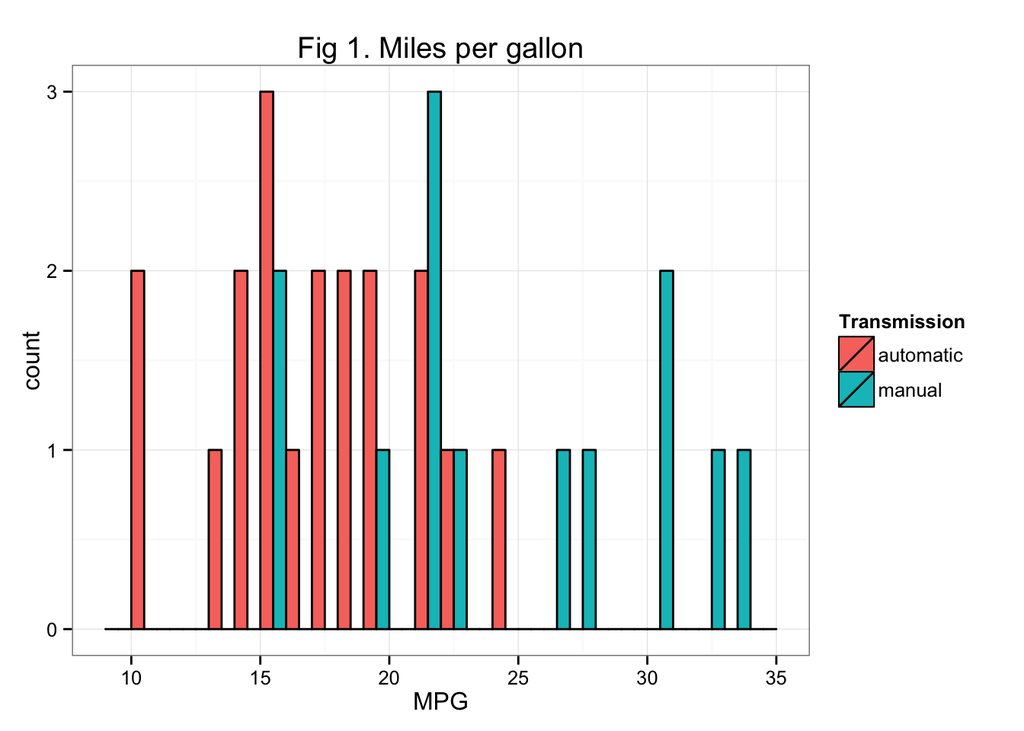

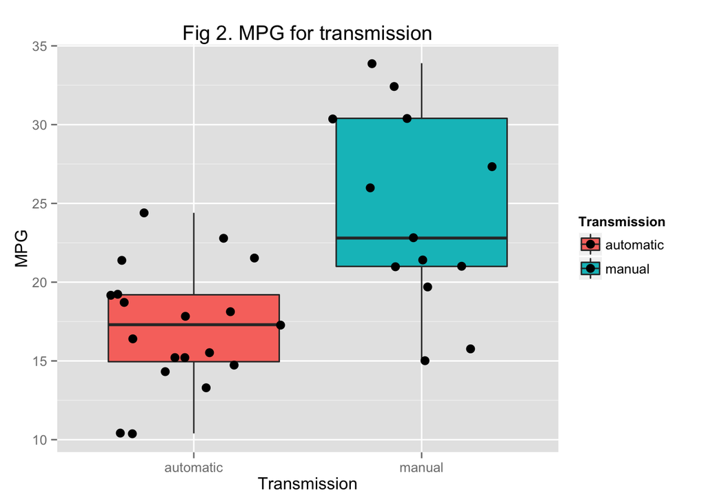

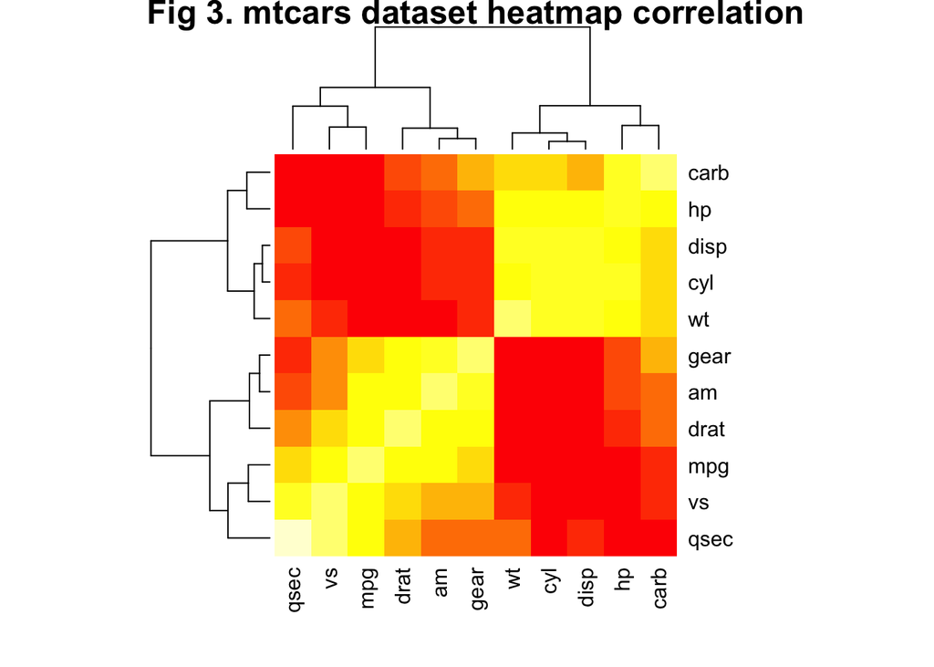

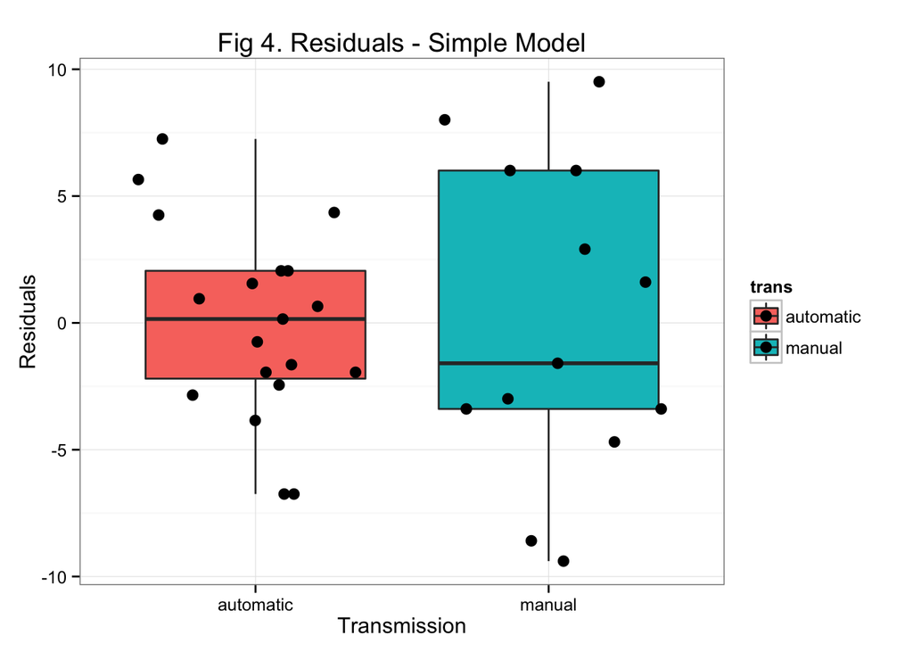

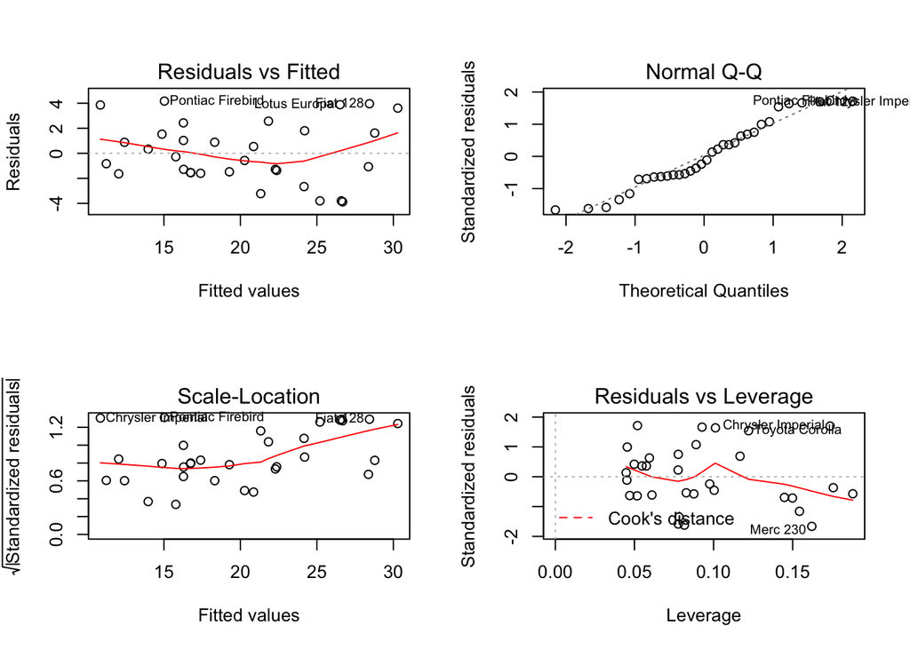